# Lab 7: Event selection optimization

```python
%matplotlib inline
import numpy as np
import matplotlib as mpl
import matplotlib.pyplot as plt
import scipy
from scipy import stats
import h5py
from scipy.optimize import curve_fit
import pickle
import pandas as pd
import random

#this sets the size of the plot to something useful
plt.rcParams["figure.figsize"] = (15,10)
mpl.rcParams['agg.path.chunksize'] = 10000.
```

I will pick a pT (transverse momentum) sample for this lab different from my lab partner's. In each pT sample, there are dedicated training samples for event selection optimization. All studies should be carried out by normalizing Higgs and QCD samples in each pT sample to give expected yields accordingly.

I will be choosing a low pT sample, while my partner chooses a high pT sample.

```python
infile = open("higgs_100000_pt_250_500.pkl", 'rb')
higgsData = pickle.load(infile)
infile2 = open("qcd_100000_pt_250_500.pkl", 'rb')
qcdData = pickle.load(infile2)
qcdData.keys()
higgsData.keys()
```

```
Index(['pt', 'eta', 'phi', 'mass', 'ee2', 'ee3', 'd2', 'angularity', 't1',
       't2', 't3', 't21', 't32', 'KtDeltaR'],
      dtype='object')
```

### Part 1: Make a stacked histogram plot for the feature variable: mass

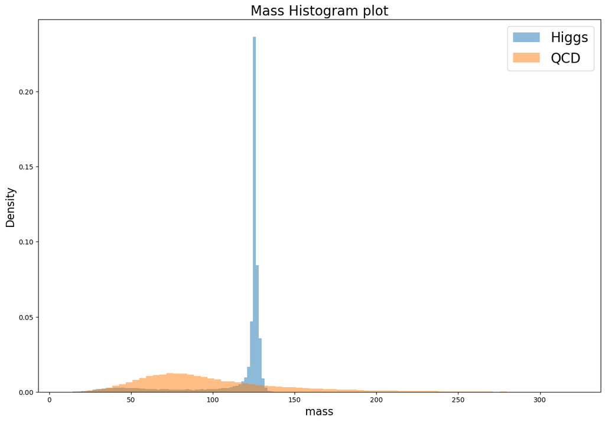

```python
plt.title('Mass Histogram plot', fontsize = 20)
plt.hist(higgsData['mass'], bins=75, alpha=0.5, density=True, label='Higgs')
plt.hist(qcdData['mass'], bins=75, alpha=0.5, density=True, label='QCD')
plt.legend(prop={"size":20})
plt.xlabel('mass', fontsize = 16)
plt.ylabel('Density', fontsize = 16)
plt.show()
```

### I. Evaluate expected significance without any event selection.

**Use Poisson statistics for significance calculation**

$N_{higgs} = 100$ and $N_{QCD} = 20000$. We know the background will be having a Poisson distribution(with mean of $N_{QCD}$). THe Higgs Boson signal will be $N_{higgs} + N_{QCD} = 20100$

```python
signal = 20100
mean = 20000
prob = stats.poisson.cdf(signal,mean)
sigma = stats.norm.ppf(prob)
sigma
```

```
0.7112259282313185
```

The sigma value is only 0.711 right now without any event selection

The value of approximation $N_{Higgs} / \sqrt{N_{QCD}}$ is given by $100 / \sqrt{20000}$

```python
100 / 20000 **(1/2)
```

```
0.7071067811865475
```

The value of approximation $N_{Higgs} / \sqrt{N_{QCD}}$ is around 0.7071, very close to the significance 0.7112

### II. Identify mass cuts to optimize the expected significance.

- Try different mass cuts systematically
- Evaluate expected significance for each set of mass cuts
- Identify the set of mass cuts which give you the highest significance.

Let's first define a function that takes upper and lower bound of the cuts of an data attribute and returns expected siginificance of the data inside the cuts to make future calculation more convenient.

```python
def data_cut(low,high,attribute):
    higgs_cut = higgsData[attribute][higgsData[attribute]>low]
    higgs_cut = higgs_cut[higgs_cut<high]
    qcd_cut = qcdData[attribute][qcdData[attribute]>low]
    qcd_cut = qcd_cut[qcd_cut<high]

    #normalize data
    higgs_n = 100 * len(higgs_cut)/len(higgsData[attribute])
    qcd_n = 20000 * len(qcd_cut)/len(qcdData[attribute])
    #calculating the significance in mass cuts.
    #sig = abs(stats.norm.ppf(1-stats.poisson.cdf(higgs_n+qcd_n,qcd_n)))
    sig = stats.norm.ppf(stats.poisson.cdf(higgs_n+qcd_n,qcd_n))
    print(f"Significance for {attribute} from {low} to {high} is given by {sig}")
    return higgs_cut, qcd_cut, sig
```

Now we try different mass cuts systematically. From the plot, the mass of higgs data seems to gather centered around halfway between 100 and 150. Let's take 125 as the center, and gradually increase our bounds for cuts to see where the maximum significance occurs

```python
for i in range(1, 25):
    low = 125 - i
    high = 125 + i
    data_cut(low, high, 'mass')
```

```
Significance for mass from 124 to 126 is given by 2.680060221998367
Significance for mass from 123 to 127 is given by 2.8005927074336725
Significance for mass from 122 to 128 is given by 2.6935775970561924
Significance for mass from 121 to 129 is given by 2.5444257955236136
Significance for mass from 120 to 130 is given by 2.4116886489259253
Significance for mass from 119 to 131 is given by 2.25359264493605
Significance for mass from 118 to 132 is given by 2.124302638592409
Significance for mass from 117 to 133 is given by 2.0061161370578713
Significance for mass from 116 to 134 is given by 1.907389709614412
Significance for mass from 115 to 135 is given by 1.821128376719804
Significance for mass from 114 to 136 is given by 1.7305409494583595
Significance for mass from 113 to 137 is given by 1.6583937228122008
Significance for mass from 112 to 138 is given by 1.5997192774744415
Significance for mass from 111 to 139 is given by 1.5516995774734932
Significance for mass from 110 to 140 is given by 1.4950732194239207
Significance for mass from 109 to 141 is given by 1.4521818605630064
Significance for mass from 108 to 142 is given by 1.4258611321463526
Significance for mass from 107 to 143 is given by 1.3774860680427363
Significance for mass from 106 to 144 is given by 1.3420766344065775
Significance for mass from 105 to 145 is given by 1.3246853865825685
Significance for mass from 104 to 146 is given by 1.2823811541678425
Significance for mass from 103 to 147 is given by 1.2621836118377698
Significance for mass from 102 to 148 is given by 1.2332627510756096
Significance for mass from 101 to 149 is given by 1.1967886868663218
```

From these choice, the mass cut of range (123, 127) gives use the highest significance, around 2.8005

```python
BestCut = data_cut(123, 127, 'mass');
```

```
Significance for mass from 123 to 127 is given by 2.8005927074336725
```

### III. Make two sets of stacked histogram plots for the rest of the features.

- **Set A without any event selection**
  - **identify another feature as discriminative as mass(i.e. equal or better significance after feature cut)**

The rest of the features are given by:

```python
higgsData.keys()
```

```
Index(['pt', 'eta', 'phi', 'mass', 'ee2', 'ee3', 'd2', 'angularity', 't1',
       't2', 't3', 't21', 't32', 'KtDeltaR'],
      dtype='object')
```

Let's define a function that takes feature as an input and then generate histogram plots for the feature(it's the function I used in lab5).

```python
def MakingPlots(attribute, title):
    plt.title(f'{title} distrubution')
    plt.hist(higgsData[attribute], bins=75, alpha=0.5, density=True, label='Higgs')
    plt.hist(qcdData[attribute], bins=75, alpha=0.5, density=True, label='QCD')
    plt.legend(prop={"size":20})
    plt.xlabel(f'{attribute}',fontsize = 16)
    plt.ylabel('Density',fontsize = 16)
    plt.show()
```

Now let's plot all the features.

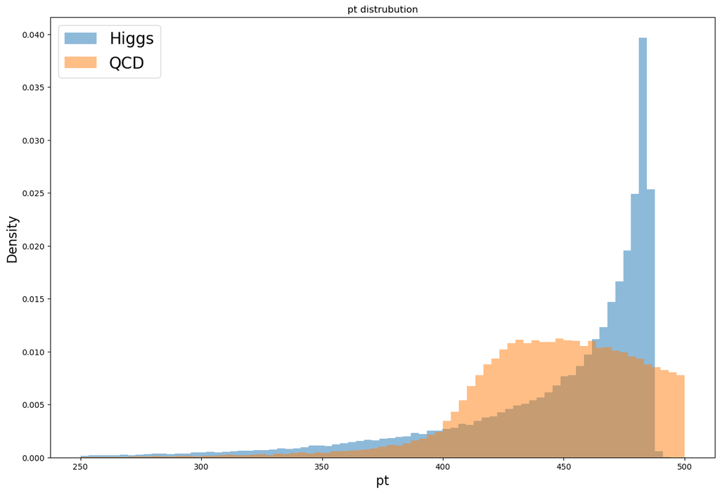

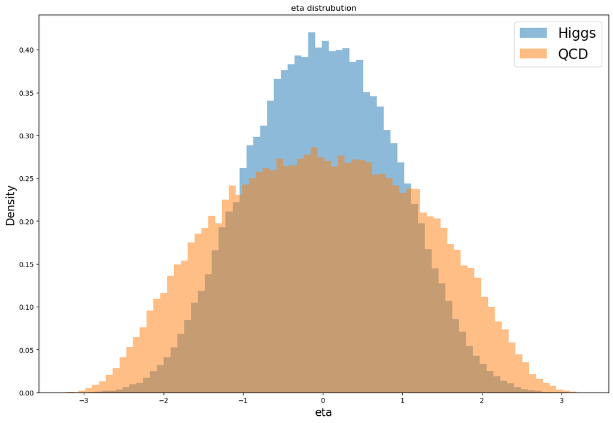

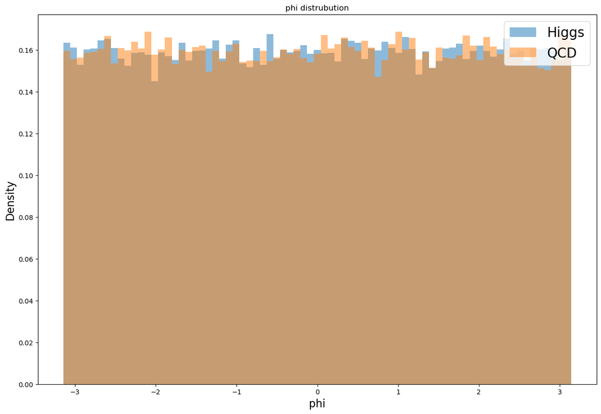

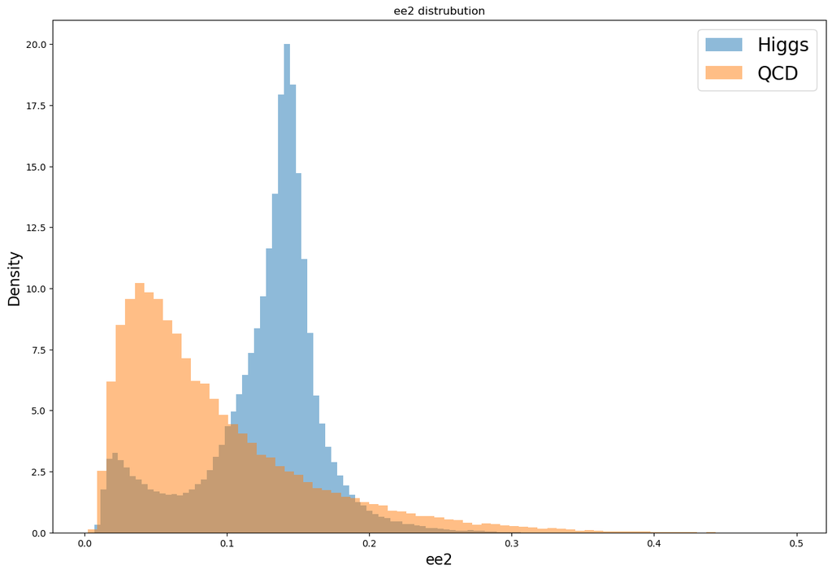

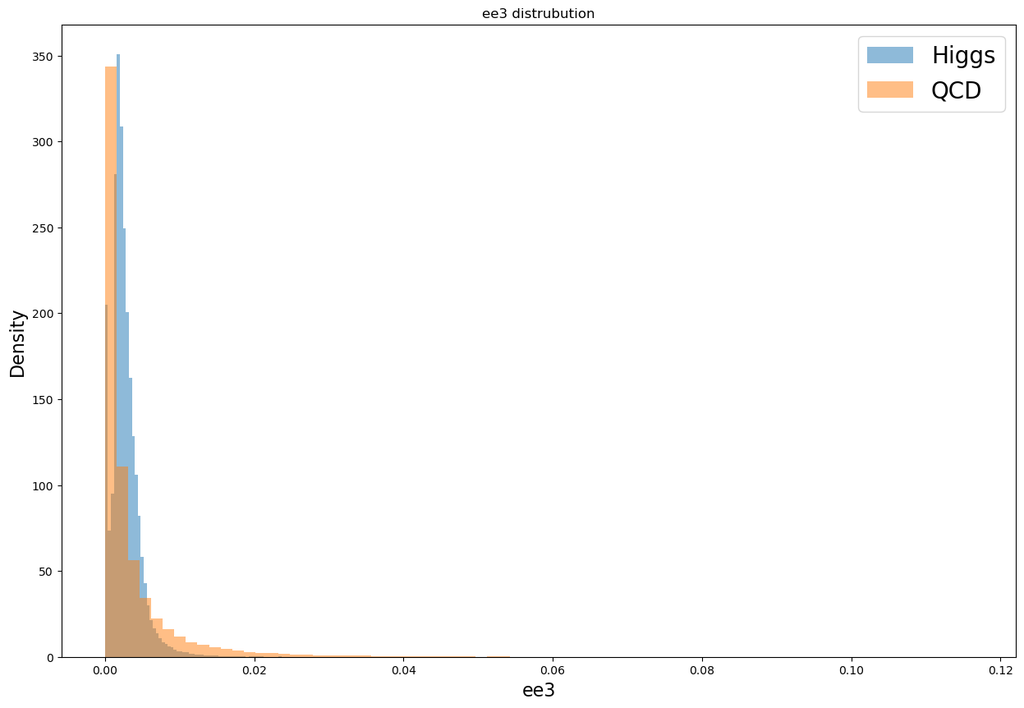

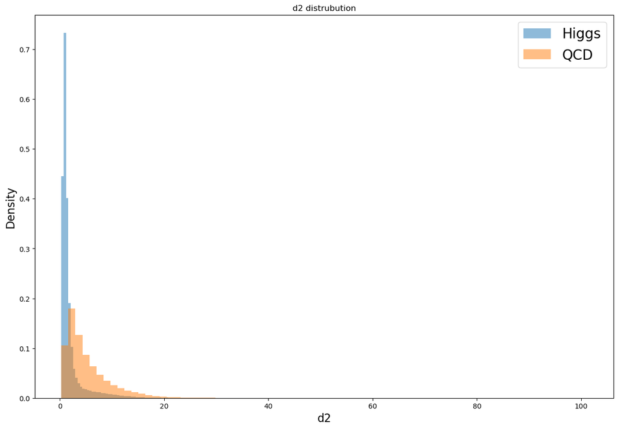

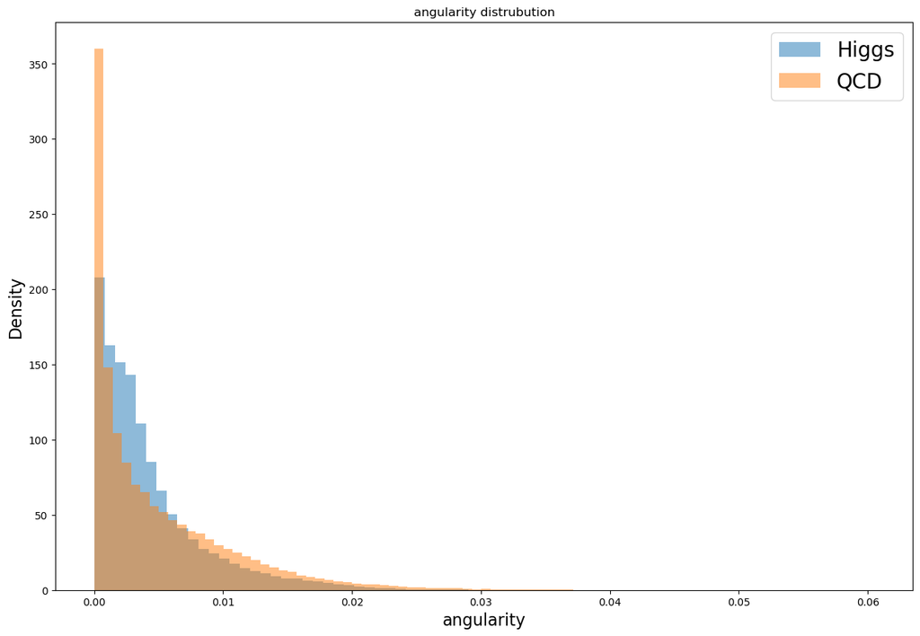

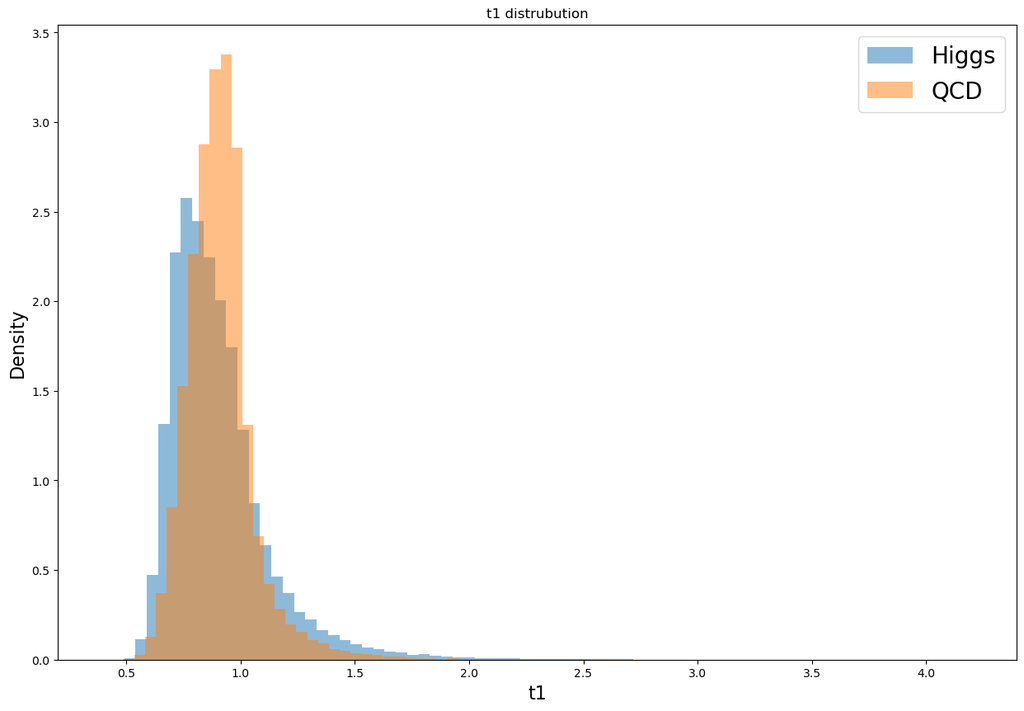

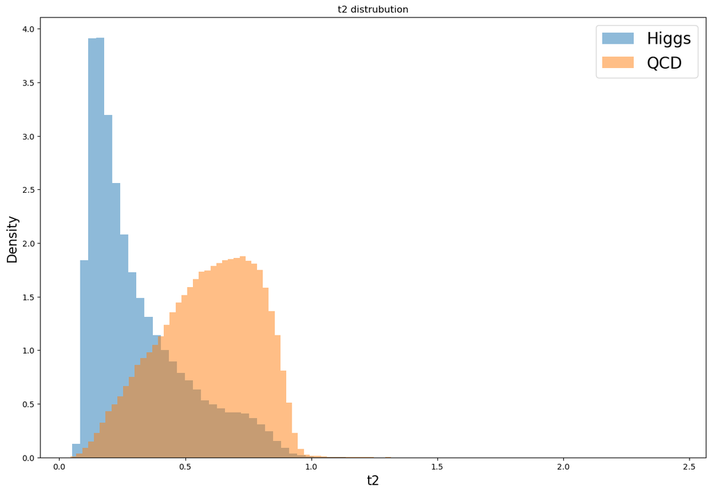

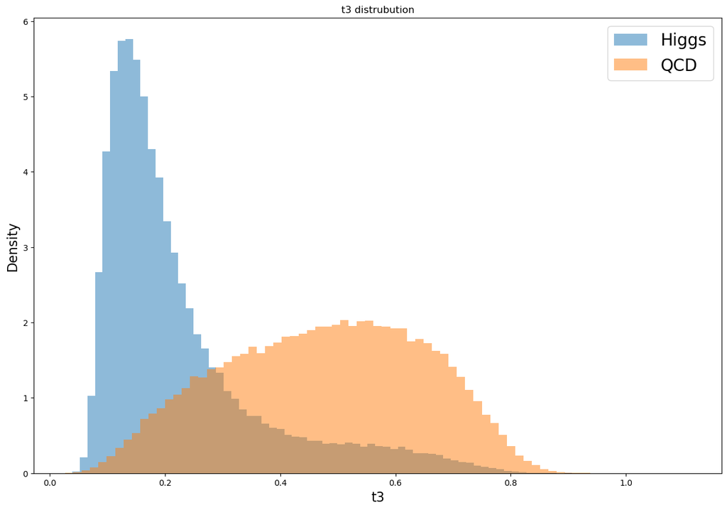

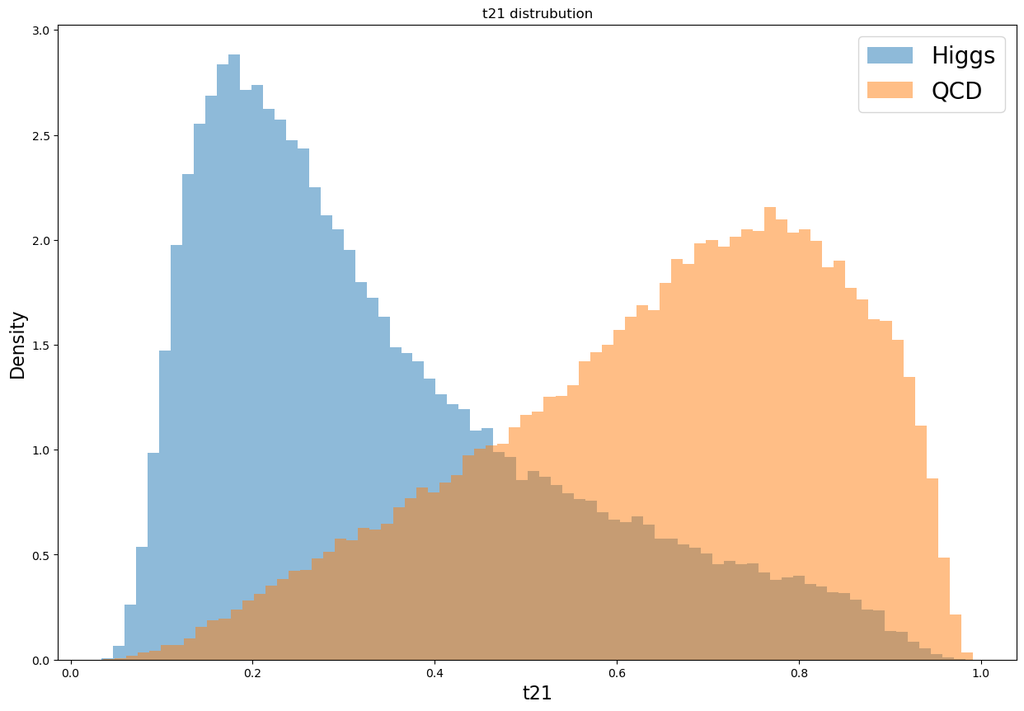

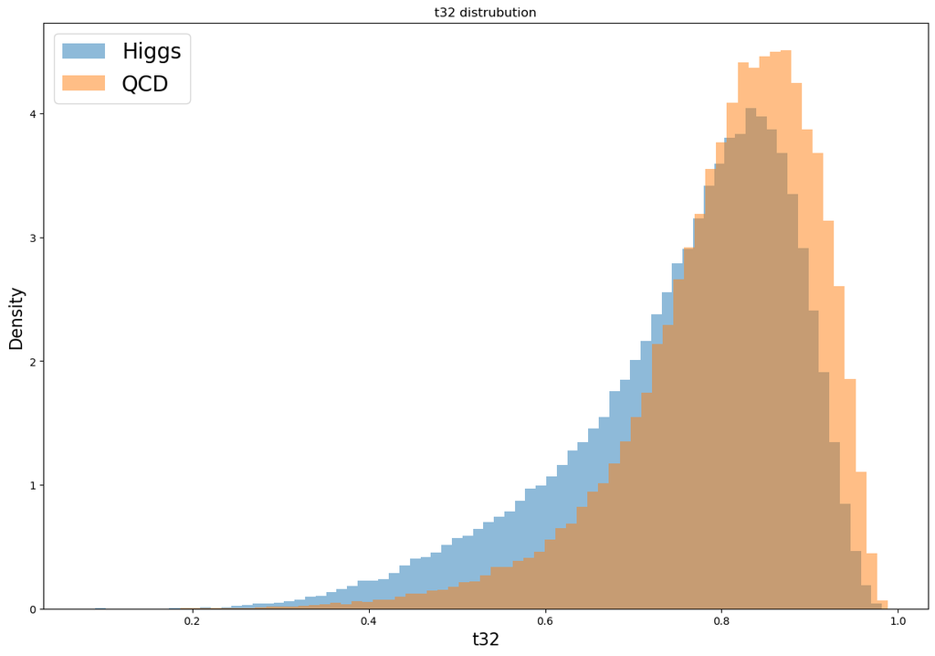

[1 more figures not shown]

```python
for i in range(14):
    if i != 3: #exclude mass feature
        key = higgsData.keys()[i]
        MakingPlots(key, key)
```

For all those features, the distributions of pt, ee2, t2, t3, t21 and KtDeltaR has a larger discrimination power between the signal(higgs) and background(QCD). Those features may be classified as being as discriminative as mass.

- **Set B with your optimal mass cuts**
  - **Can you identify another feature to further improve your expected signifiance?**

We can define another function, that prints the significance of the cuts of an given feature corresponding to our optimal mass cuts, and another function that plots the histograms of features with optimal cuts.

```python
def data_cut_2(attribute):
    higgs_cut = higgsData[higgsData['mass']>123]
    higgs_cut = higgs_cut[higgs_cut['mass']<127]
    higgs_cut = higgs_cut[attribute]
    qcd_cut = qcdData[qcdData['mass']>123]
    qcd_cut = qcd_cut[qcd_cut['mass']<127]
    qcd_cut = qcd_cut[attribute]
    #normalize data
    higgs_n = 100 * len(higgs_cut)/len(higgsData[attribute])
    qcd_n = 20000 * len(qcd_cut)/len(qcdData[attribute])
    #calculating the significance in mass cuts.
    sig = abs(stats.norm.ppf(1-stats.poisson.cdf(higgs_n+qcd_n,qcd_n)))
    print(f"Significance for {attribute} from mass of {123} to {127} is given by {sig}")
    return higgs_cut, qcd_cut, sig
```

```python
def MakingOptPlots(higgs, qcd, title): #function that plots histogram given optimal mass
    plt.title(f'{title} distrubution with optimal cuts')
    plt.hist(higgs, bins=75, alpha=0.5, density=True, label='Higgs')
    plt.hist(qcd, bins=75, alpha=0.5, density=True, label='QCD')
    plt.legend(prop={"size":20})
    plt.xlabel(f'{title}',fontsize = 16)
    plt.ylabel('Density',fontsize = 16)
```

For a more clear comparison, I will plot the histogram without optimal cuts of each feature again along with the one with optimal cuts.

```
Significance for pt from mass of 123 to 127 is given by 2.8005927074336725
```

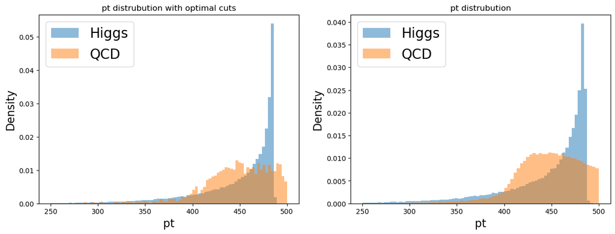

```
Significance for eta from mass of 123 to 127 is given by 2.8005927074336725
```

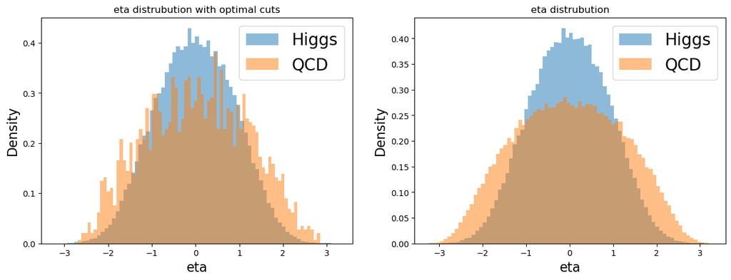

```
Significance for phi from mass of 123 to 127 is given by 2.8005927074336725
```

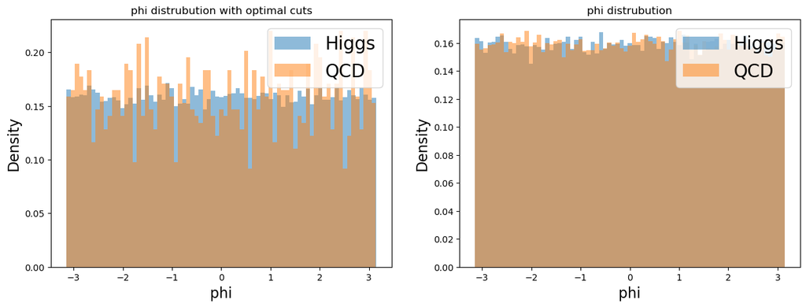

```
Significance for ee2 from mass of 123 to 127 is given by 2.8005927074336725
```

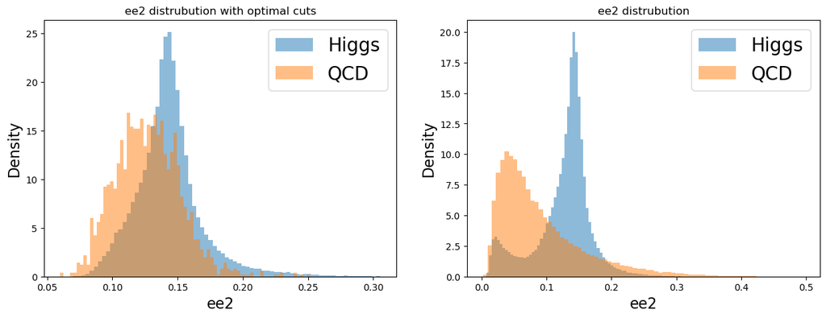

```
Significance for ee3 from mass of 123 to 127 is given by 2.8005927074336725
```

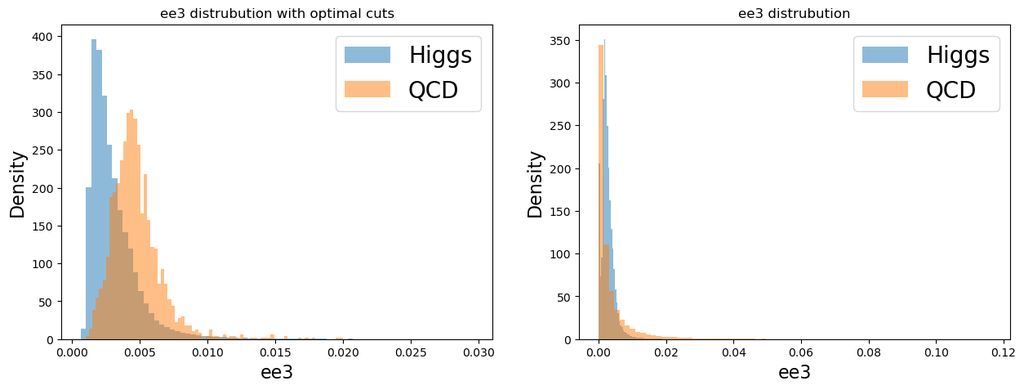

```
Significance for d2 from mass of 123 to 127 is given by 2.8005927074336725
```

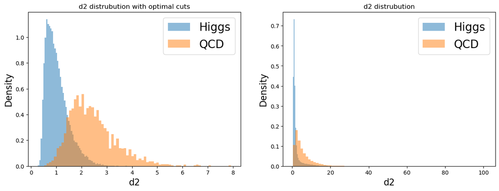

```
Significance for angularity from mass of 123 to 127 is given by 2.8005927074336725
```

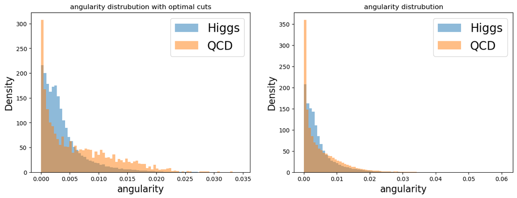

```
Significance for t1 from mass of 123 to 127 is given by 2.8005927074336725
```

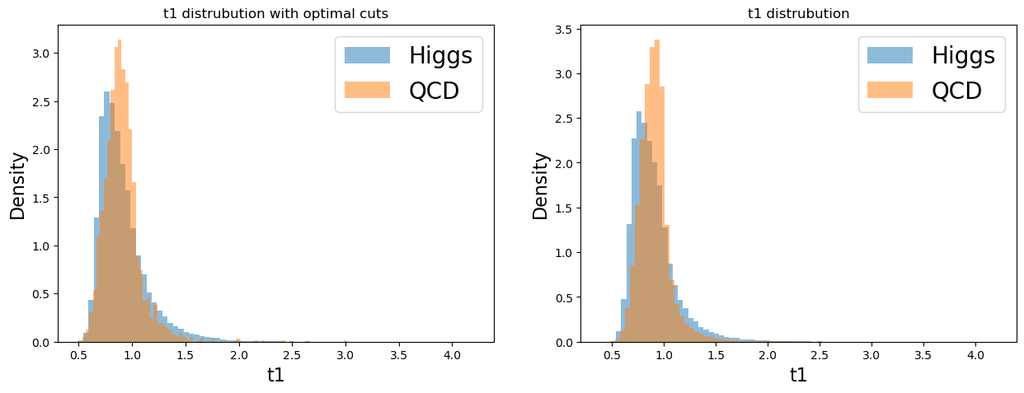

```
Significance for t2 from mass of 123 to 127 is given by 2.8005927074336725
```

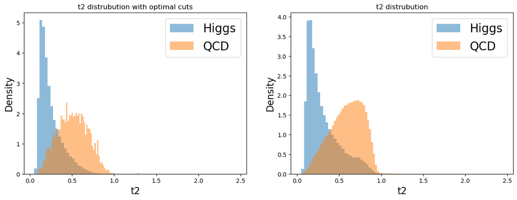

```
Significance for t3 from mass of 123 to 127 is given by 2.8005927074336725
```

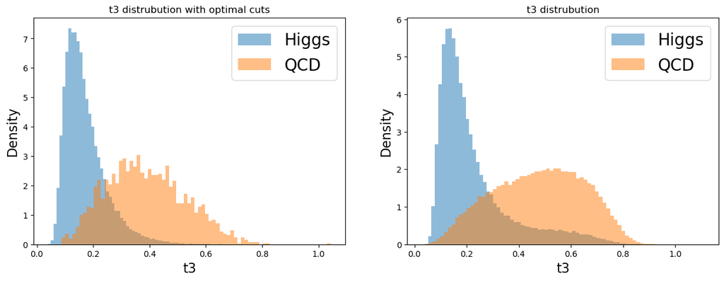

```
Significance for t21 from mass of 123 to 127 is given by 2.8005927074336725
```

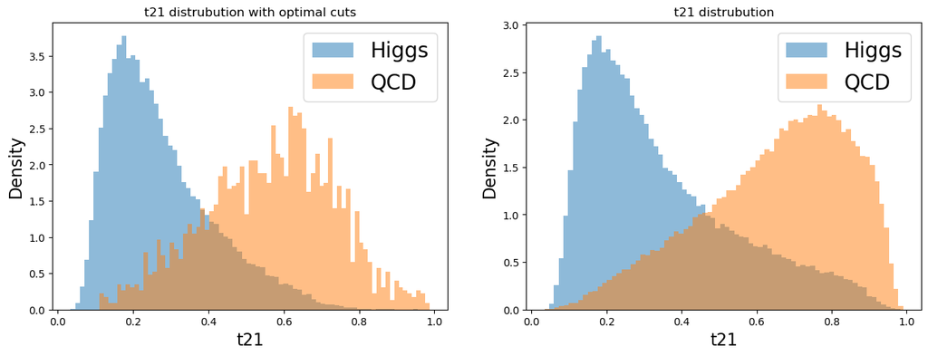

```
Significance for t32 from mass of 123 to 127 is given by 2.8005927074336725
```

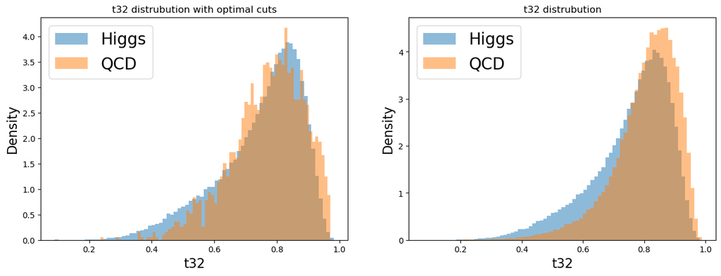

```
Significance for KtDeltaR from mass of 123 to 127 is given by 2.8005927074336725
```

[1 more figures not shown]

```python
for i in range(14):
    if i != 3: #exclude mass feature
        key = higgsData.keys()[i]
        cut_data = data_cut_2(key)
        plt.figure(figsize=(15,5))
        plt.subplot(1,2,1)
        MakingOptPlots(cut_data[0], cut_data[1], key)
        plt.subplot(1,2,2)
        MakingPlots(key, key)
        plt.show()
```

From the comparisons, we can see our mass cuts eliminate some amount of background(QCD) data while keeping signals(Higgs) data. From the graph, the features being most discriminative after optimal cuts include ee3, d2, t3, t2 KtDeltaR, etc

### IV. Optimize event selections using multiple features (if necessary)

- **Find a set of feature cuts which achieve high expected significance.**
  - **Compare significance (before/after event selection) derived in your pT samples to your lab partner. Describe your findings.**

In previous section, we classify ee3, d2, t3, t2, KtDeltaR as being most discriminative after our mass cuts. So we can try out few cuts systematically on each of them and find out which one gives highest significance.

The first one will be **ee3**.

```python
def data_cut_3(attribute,low,high,higgs,qcd): #function for our second cut after mass cut
    higgs_cut = higgs[higgs>=low]
    higgs_cut = higgs_cut[higgs_cut<high]
    qcd_cut = qcd[qcd>low]
    qcd_cut = qcd_cut[qcd_cut<high]

    #normalize data
    higgs_n = 100 * len(higgs_cut)/len(higgsData['mass'])
    qcd_n = 20000 * len(qcd_cut)/len(qcdData['mass'])
    #calculating the significance.
    sig = stats.norm.ppf(stats.poisson.cdf(higgs_n+qcd_n,qcd_n))
    print(f"Significance for {attribute} from {low} to {high} is given by {sig}")
    return higgs_cut, qcd_cut, sig
```

```python
ee3_cut = data_cut_2('ee3')
```

```
Significance for ee3 from mass of 123 to 127 is given by 2.8005927074336725
```

```python
for i in range(1, 30):
    low = 0
    high =  0.0005 * i
    data_cut_3('ee3', low, high, ee3_cut[0], ee3_cut[1])
```

```
Significance for ee3 from 0 to 0.0005 is given by inf
Significance for ee3 from 0 to 0.001 is given by 0.9105386773865511
Significance for ee3 from 0 to 0.0015 is given by 3.4945314490920794
Significance for ee3 from 0 to 0.002 is given by 4.431237759232123
Significance for ee3 from 0 to 0.0025 is given by 4.8773593233478145
Significance for ee3 from 0 to 0.003 is given by 4.429892559295927
Significance for ee3 from 0 to 0.0035 is given by 3.9812261073996535
Significance for ee3 from 0 to 0.004 is given by 3.60968550103396
Significance for ee3 from 0 to 0.0045000000000000005 is given by 3.3145938799077563
Significance for ee3 from 0 to 0.005 is given by 3.127691125181382
Significance for ee3 from 0 to 0.0055 is given by 3.003211677152546
Significance for ee3 from 0 to 0.006 is given by 2.9475227256593186
Significance for ee3 from 0 to 0.006500000000000001 is given by 2.864131223429369
Significance for ee3 from 0 to 0.007 is given by 2.823976897619421
Significance for ee3 from 0 to 0.0075 is given by 2.836803476035125
Significance for ee3 from 0 to 0.008 is given by 2.8079253600399783
Significance for ee3 from 0 to 0.0085 is given by 2.828701473512787
Significance for ee3 from 0 to 0.009000000000000001 is given by 2.8180268956957297
Significance for ee3 from 0 to 0.0095 is given by 2.8109773758600007
Significance for ee3 from 0 to 0.01 is given by 2.82839213826293
Significance for ee3 from 0 to 0.0105 is given by 2.831801562025306
Significance for ee3 from 0 to 0.011 is given by 2.8109313530552362
Significance for ee3 from 0 to 0.0115 is given by 2.8178704888868653
Significance for ee3 from 0 to 0.012 is given by 2.8143893157128335
Significance for ee3 from 0 to 0.0125 is given by 2.8213157171648384
Significance for ee3 from 0 to 0.013000000000000001 is given by 2.810921030065463
Significance for ee3 from 0 to 0.0135 is given by 2.8005299553917204
Significance for ee3 from 0 to 0.014 is given by 2.838618515763799
Significance for ee3 from 0 to 0.0145 is given by 2.8074655525182917
```

Then we go for **d2**. Since, from the plot, there is no background data below around 0.5, we start our cut from 0.5, or otherwise we would get inifinity for our significance. It will also be the reason of why our lower bound is not 0 for our several other features later.|

```python
d2_cut = data_cut_2('d2')
for i in range(1, 20):
    low = 0.5
    high =  0.5 + 0.1 * i
    data_cut_3('d2', low, high, d2_cut[0], d2_cut[1])
```

```
Significance for d2 from mass of 123 to 127 is given by 2.8005927074336725
Significance for d2 from 0.5 to 0.6 is given by 5.252784133721291
Significance for d2 from 0.5 to 0.7 is given by 6.430487205298845
Significance for d2 from 0.5 to 0.8 is given by 7.658076869584887
Significance for d2 from 0.5 to 0.9 is given by 8.125890664701908
Significance for d2 from 0.5 to 1.0 is given by 7.905689996005889
Significance for d2 from 0.5 to 1.1 is given by 7.613653990412284
Significance for d2 from 0.5 to 1.2000000000000002 is given by 7.1610745847378485
Significance for d2 from 0.5 to 1.3 is given by 6.895179140045348
Significance for d2 from 0.5 to 1.4 is given by 6.404763052733528
Significance for d2 from 0.5 to 1.5 is given by 5.777126200114204
Significance for d2 from 0.5 to 1.6 is given by 5.316516401524481
Significance for d2 from 0.5 to 1.7000000000000002 is given by 4.988137566782697
Significance for d2 from 0.5 to 1.8 is given by 4.629280534539818
Significance for d2 from 0.5 to 1.9000000000000001 is given by 4.3068777551344075
Significance for d2 from 0.5 to 2.0 is given by 4.151483315627978
Significance for d2 from 0.5 to 2.1 is given by 3.901725308027783
Significance for d2 from 0.5 to 2.2 is given by 3.7918937266963724
Significance for d2 from 0.5 to 2.3 is given by 3.6379070858180387
Significance for d2 from 0.5 to 2.4000000000000004 is given by 3.52868046342046
```

The highest significance is given by 8.125890664701908, when d2 is from 0.5 to 0.9

Next is **t3**.

```python
t3_cut = data_cut_2('t3')
for i in range(1, 20):
    low = 0.0
    high =  0.1 + 0.01 * i
    data_cut_3('t3', low, high, t3_cut[0], t3_cut[1])
```

```
Significance for t3 from mass of 123 to 127 is given by 2.8005927074336725
Significance for t3 from 0.0 to 0.11 is given by 4.665820914703096
Significance for t3 from 0.0 to 0.12000000000000001 is given by 5.463424239253305
Significance for t3 from 0.0 to 0.13 is given by 6.158767786489284
Significance for t3 from 0.0 to 0.14 is given by 6.784088001093369
Significance for t3 from 0.0 to 0.15000000000000002 is given by 6.865798299291717
Significance for t3 from 0.0 to 0.16 is given by 6.708351097805884
Significance for t3 from 0.0 to 0.17 is given by 6.692703508059472
Significance for t3 from 0.0 to 0.18 is given by 6.736181401474975
Significance for t3 from 0.0 to 0.19 is given by 6.4624093150905955
Significance for t3 from 0.0 to 0.2 is given by 6.407657211904384
Significance for t3 from 0.0 to 0.21000000000000002 is given by 6.212007491359777
Significance for t3 from 0.0 to 0.22 is given by 5.958555363081295
Significance for t3 from 0.0 to 0.23 is given by 5.787172548271228
Significance for t3 from 0.0 to 0.24000000000000002 is given by 5.63646691780331
Significance for t3 from 0.0 to 0.25 is given by 5.4992399544706565
Significance for t3 from 0.0 to 0.26 is given by 5.300058232071422
Significance for t3 from 0.0 to 0.27 is given by 5.1676006945091295
Significance for t3 from 0.0 to 0.28 is given by 4.950321188661096
Significance for t3 from 0.0 to 0.29000000000000004 is given by 4.843393179890306
```

The highest significance is given by 6.865798299291717, when t3 is from 0 to 0.15

Next is **t2**.

```python
t2_cut = data_cut_2('t2')
for i in range(1, 20):
    low = 0
    high =  0.1 + 0.01 * i
    data_cut_3('t2', low, high, t2_cut[0], t2_cut[1])
```

```
Significance for t2 from mass of 123 to 127 is given by 2.8005927074336725
Significance for t2 from 0 to 0.11 is given by 2.6819384005470015
Significance for t2 from 0 to 0.12000000000000001 is given by 3.7029629270083224
Significance for t2 from 0 to 0.13 is given by 4.302252785961888
Significance for t2 from 0 to 0.14 is given by 5.159084467380833
Significance for t2 from 0 to 0.15000000000000002 is given by 5.60856553963883
Significance for t2 from 0 to 0.16 is given by 6.032491685546732
Significance for t2 from 0 to 0.17 is given by 6.192652051501177
Significance for t2 from 0 to 0.18 is given by 6.224362814436412
Significance for t2 from 0 to 0.19 is given by 6.321547966413318
Significance for t2 from 0 to 0.2 is given by 6.239594194328562
Significance for t2 from 0 to 0.21000000000000002 is given by 6.043018412839586
Significance for t2 from 0 to 0.22 is given by 6.0093498545437365
Significance for t2 from 0 to 0.23 is given by 5.957811541924923
Significance for t2 from 0 to 0.24000000000000002 is given by 5.79738163992647
Significance for t2 from 0 to 0.25 is given by 5.748261821741813
Significance for t2 from 0 to 0.26 is given by 5.644978599760931
Significance for t2 from 0 to 0.27 is given by 5.65514819803148
Significance for t2 from 0 to 0.28 is given by 5.396913982871968
Significance for t2 from 0 to 0.29000000000000004 is given by 5.362268914497143
```

The highest significance is given by 6.321547966413318, when t2 is from 0 to 0.19

The last one is **KtDeltaR**.

```python
KtDeltaR_cut = data_cut_2('KtDeltaR')
for i in range(1, 20):
    low = 0.4
    high =  0.4 + 0.05 * i
    data_cut_3('KtDeltaR', low, high, KtDeltaR_cut[0], KtDeltaR_cut[1])
```

```
Significance for KtDeltaR from mass of 123 to 127 is given by 2.8005927074336725
Significance for KtDeltaR from 0.4 to 0.45 is given by 0.3014595030352241
Significance for KtDeltaR from 0.4 to 0.5 is given by 1.180080830271585
Significance for KtDeltaR from 0.4 to 0.55 is given by 2.2914306257837844
Significance for KtDeltaR from 0.4 to 0.6000000000000001 is given by 2.892764119772237
Significance for KtDeltaR from 0.4 to 0.65 is given by 3.2398017099332894
Significance for KtDeltaR from 0.4 to 0.7000000000000001 is given by 3.4080944293360202
Significance for KtDeltaR from 0.4 to 0.75 is given by 3.458280297109625
Significance for KtDeltaR from 0.4 to 0.8 is given by 3.565407630921966
Significance for KtDeltaR from 0.4 to 0.8500000000000001 is given by 3.5376021845063397
Significance for KtDeltaR from 0.4 to 0.9 is given by 3.558190556740082
Significance for KtDeltaR from 0.4 to 0.9500000000000001 is given by 3.505305466070939
Significance for KtDeltaR from 0.4 to 1.0 is given by 3.511143236616753
Significance for KtDeltaR from 0.4 to 1.05 is given by 3.4972442247798523
Significance for KtDeltaR from 0.4 to 1.1 is given by 3.4972442247798523
Significance for KtDeltaR from 0.4 to 1.15 is given by 3.4972442247798523
Significance for KtDeltaR from 0.4 to 1.2000000000000002 is given by 3.4972442247798523
Significance for KtDeltaR from 0.4 to 1.25 is given by 3.4972442247798523
Significance for KtDeltaR from 0.4 to 1.3 is given by 3.4972442247798523
Significance for KtDeltaR from 0.4 to 1.35 is given by 3.4972442247798523
```

The highest significance is given by 3.565407630921966, when KtDeltaR is from 0.4 to 0.8

So, from our result, d2 gives the highest sigfinicance, which is over 8!

```python
!jupyter nbconvert --to html Lab7_notebook.ipynb
```

```
[NbConvertApp] Converting notebook Lab7_notebook.ipynb to html
[NbConvertApp] Writing 947276 bytes to Lab7_notebook.html
```